# Engineering Mechanics - Dynamics

บำรุง พ่วงเกิด

ปีการศึกษา ๒๕๖๐

# 1 จลนศาสตร์ของอนุภาค

## 1.1 การบรรยายการเคลื่อนที่

การบรรยายการเคลื่อนที่ ย่อมประกอบไปด้วย

- ตำแหน่งของอนุภาค (position) เป็นเวกเตอร์ ใช้สัญลักษณ์แทนคือ $\vec{r}$
- ความเร็วของอนุภาค (velocity) เป็นเวกเตอร์ ใช้สัญลักษณ์แทนคือ $\vec{v}$
- ความเร่งของอนุภาค (accerelation) เป็นเวกเตอร์ ใช้สัญลักษณ์แทนคือ $\vec{a}$

ซึ่งทั้งสามประการนี้ ขึ้นกับเวลา (time) หรือมีเวลาเป็นตัวแปรเสริมนั่นเอง

ตำแหน่งของอนุภาคถูกบรรยายด้วยเวกเตอร์บอกตำแหน่ง $\vec{r}(t)$ ซึ่งจะบ่งบอกถึง วิถีของการเคลื่อนที่ (trajectory) ซึ่งประกอบไปด้วย

- เส้นทางการเคลื่อนที่ (path) เป็นความสัมพันธ์ระหว่างองค์ประกอบของเวกเตอร์บอกตำแหน่ง
- การเคลื่อนที่ (motion) บอกถึงตำแหน่งของวัตถุ เมื่อเวลาเปลี่ยนไป

#### 1.1.0.1 นิยามของความเร็ว $\vec{v}(t)$

$$\eqalign{\vec v\left( t \right) & \equiv \mathop {\lim }\limits_{\Delta t \to 0}
{{\vec r\left( {t + \Delta t} \right) - \vec r\left( t \right)} \over {\Delta t}} \cr
& = \lim_{\Delta t \to 0} {{\Delta \vec r(t)} \over {\Delta t}} = \dot{\vec r}(t)
}$$

โดยที่ $\Delta \vec r(t)$ คือเวกเตอร์การกระจัด (displacement vector)

อัตราการเปลี่ยนแปลงของเวกเตอร์บอกตำแหน่ง ทำให้ได้วิถีของความเร็ว (hodograph) เพื่อนำไปใช้ในนิยามของการหาความเร่งต่อไป

#### 1.1.0.2 นิยามของความเร่ง $\vec{a}(t)$

$$\vec a\left( t \right) \equiv \mathop {\lim }\limits_{\Delta t \to 0}
{{\vec v\left( {t + \Delta t} \right) - \vec v\left( t \right)} \over {\Delta t}} = \dot{\vec{v}}(t)$$

## 1.2 การเคลื่อนที่โดยทั่วไปของอนุภาค - เคลื่อนที่ในแนววิถีโค้ง

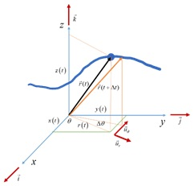

การบรรยายการเคลื่อนที่ที่เหมาะสม ขึ้นกับสมมาตรของวิถีของการเคลื่อนที่ หรือสมมาตรของการเคลื่อนที่ สมมาตรของการเคลื่อนที่แบ่งได้เป็นกรณีต่างๆ คือ

### 1.2.1 การเคลื่อนที่แบบไร้สมมาตร

การเคลื่อนที่แบบไร้สมมาตร จะถูกบรรยายโดยการใช้พิกัดฉาก (rectangular หรือ cartesian coordinates) เวกเตอร์ทิศทางหนึ่งหน่วย $\;\vec{i} \; \vec{j} \;$ และ $\;\vec{k}\;$ เป็นเวกเตอร์ที่ชี้ในทิศเดิมตลอด จึงไม่มีอัตราการเปลี่ยนแปลง ของเวกเตอร์ทิศทางหนึ่งหน่วย

อัตราการเปลี่ยนแปลงเวกเตอร์หนึ่งหน่วย

$$\dot{\vec{i}} = \dot{\vec{j}} = \dot{\vec{k}} = \vec{0}$$

การบรรยายการเคลื่อนที่

$$\eqalign{\vec{r}(t) & = x(t)\;\vec{i} + y(t)\;\vec{j} + z(t)\;\vec{k} \cr
\vec{v}(t) & = \dot{x}(t)\;\vec{i} + \dot{y}(t)\;\vec{j} + \dot{z}(t)\;\vec{k} \cr
\vec{a}(t) & = \ddot{x}(t)\;\vec{i} + \ddot{y}(t)\;\vec{j} + \ddot{z}(t)\;\vec{k}}$$

#### 1.2.1.1 ความเร่งตามแนวแกน - องค์ประกอบฉาก (Rectangular components)

$$\boxed{a_x = \ddot{x}(t) \qquad a_y = \ddot{y}(t) \qquad a_z = \ddot{z}(t)}$$

ขนาดของความเร่ง

$$a = \sqrt{a_x^2 + a_y^2 + a_z^2} = \sqrt{\Big(\ddot{x}(t)\Big)^2
+ \Big(\ddot{y}(t)\Big)^2 + \Big(\ddot{z}(t)\Big)^2}$$

ตัวอย่าง

- การเคลื่อนที่ของขีปนาวุธ (Projectile motion)
  $$a_x = 0 \qquad a_y = -g$$
- การสั่นน้อยมากของสปริง (Simple harmonic motion)
  $$a_x = -{\omega}^2\;x$$

### 1.2.2 การเคลื่อนที่แบบมีสมมาตรรอบแกน

การเคลื่อนที่แบบมีสมมาตรรอบแกน $z$ จะถูกบรรยายโดยการใช้พิกัดทรงกระบอก (cylindrical coordinates) เมื่อเทียบกับพิกัดฉาก

$$r(t) = \sqrt{(x(t))^2 + (y(t))^2}$$

เวกเตอร์ทิศทางหนึ่งหน่วย $\; \vec{u}_r\;$ และ $\;\vec{u}_{\theta} \;$ เป็นเวกเตอร์ที่ชี้ในทิศที่เปลี่ยนไปกับเวลา ในขณะที่ $\;\vec{k}\;$ เป็นเวกเตอร์ที่ชี้ในทิศเดิมตลอด

อัตราการเปลี่ยนแปลงของเวกเตอร์หนึ่งหน่วย

$$\dot{\vec{u}}_{r} = \dot{\theta}(t)\; \vec{u}_{\theta} \qquad
\dot{\vec{u}}_{\theta} = - \dot{\theta}(t)\; \vec{u}_{r} \qquad
\dot{\vec{k}}= \vec{0}$$

การบรรยายการเคลื่อนที่

$$\eqalign{\vec{r}(t) & = r(t) \; \vec{u}_r + z(t)\;\vec{k} \cr
\vec{v}(t) = \vec{\dot{r}}(t) & = \dot{r}(t) \;\vec{u}_r +
r(t)\; \dot{\vec{u}}_r + \dot{z}(t)\;\vec{k}\cr
& = \dot{r}(t) \;\vec{u}_r + r(t)\; \dot{\theta}(t)\;\vec{u}_{\theta} + \dot{z}(t)\;\vec{k} \cr
\vec{a}(t) = \vec{\dot{v}}(t) & = \ddot{r}(t) \;\vec{u}_r + \dot{r}(t) \;\dot{\vec{u}}_r +
\dot{\Big( r(t)\; \dot{\theta}(t)\Big)}\;\vec{u}_{\theta} +
\Big(r(t)\;\dot{\theta}(t)\Big)\;\dot{\vec{u}}_{\theta}+
\dot{z}(t)\;\vec{k} \cr
& = \ddot{r}(t) \;\vec{u}_r + \dot{r}(t) \; \dot{\theta}(t)\;\vec{u}_{\theta} +
\dot{r}(t) \; \dot{\theta}(t)\;\vec{u}_{\theta}
+ r(t)\; \ddot{\theta}(t)\;\vec{u}_{\theta}
- r(t)\;\dot{\theta}^2(t)\;\vec{u}_{r} +
\ddot{z}(t)\;\vec{k} \cr
& = \Big(\ddot{r}(t) - r(t)\;\dot{\theta}^2(t)\Big) \;\vec{u}_r +
\Big(2\; \dot{r}(t) \; \dot{\theta}(t)\ +
r(t)\; \ddot{\theta}(t)\Big) \;\vec{u}_{\theta} +
\ddot{z}(t)\;\vec{k} \cr
}$$

#### 1.2.2.1 ความเร่งตามแนวแกน - องค์ประกอบทรงกระบอก (Cylindrical components)

$$\boxed{ a_r = \Big(\ddot{r}(t) - r(t)\;\dot{\theta}^2(t)\Big) \qquad
a_{\theta} = \Big(2\; \dot{r}(t) \; \dot{\theta}(t)\ +
r(t)\; \ddot{\theta}(t)\Big) \qquad
a_z = \ddot{z}(t)}$$

ขนาดของความเร่ง

$$a = \sqrt{\Big(\ddot{r}(t) - r(t)\;\dot{\theta}^2(t)\Big)^2 +
\Big(2\; \dot{r}(t) \; \dot{\theta}(t)\ +
r(t)\; \ddot{\theta}(t)\Big)^2 + \Big( \ddot{z}(t)\Big)^2}$$

### 1.2.3 การเคลื่อนที่แบบมีสมมาตรรอบจุดตลอด

การเคลื่อนที่แบบมีสมมาตรรอบจุดตลอดจะถูกบรรยายโดยการไปสังเกตุบนตัวอนุภาคโดยตรง ทำให้ไม่ต้องบ่งบอกถึงตำแหน่งของอนุภาค และการที่การเคลื่อนที่มีสมมาตรรอบจุดตลอด ทำให้เส้นทางการเคลื่อนที่เป็นการสร้างจากส่วนของวงกลมรัศมีต่างๆ มาต่อเรียงกัน ผู้สังเกตุมองเห็นวัตถุเคลื่อนที่ด้วยความเร็วตามแนวเส้นสัมผัสของเส้นทางการเคลื่อนที่ (tangent) ในทิศ $\vec{u}_t$ และมีทิศตั้งฉาก (normal) กับทิศเส้นสัมผัสฟังก์ชัน ชี้เข้าสู่ศูนย์กลางของวงกลม (สมมาตร) คือทิศ $\vec{u}_n$ การเคลื่อนที่มีในสองแนวทางนี้เท่านั้น แต่เพื่อให้เป็นการเคลื่อนที่ในสามมิติ ทิศตั้งฉากกับทิศสัมผัสกับทิศตั้งฉาก (binormal) ถูกสร้างมาจาก

$$\vec{u}_b = \vec{u}_t \times \vec{u}_n$$

อัตราการเปลี่ยนแปลงของเวกเตอร์หนึ่งหน่วย

$$\dot{\vec{u}}_t = \dot{\theta} \; \vec{u}_n = \frac{v_t}{\rho } \; \vec{u}_n$$

การบรรยายการเคลื่อนที่

$$\eqalign{\vec{v} & = v_t \; \vec{u}_t \cr
\vec{a} = \dot{\vec{v}} & = \dot{v}_t \; \vec{u}_t + v_t\;\dot{\vec{u}}_t \cr
& = \dot{v}_t \; \vec{u}_t + \frac{v_t^2}{\rho} \; \vec{u}_n
}$$

#### 1.2.3.1 ความเร่งในแนวแกน - องค์ประกอบแนวตั้งฉากและแนวสัมผัส (Normal-tangential components)

$$\boxed{a_t = \dot{v}_t \qquad a_n = \frac{v_t^2}{\rho} \qquad a_b = 0}$$

การเคลื่อนที่ในระนาบ เส้นทางการเคลื่อนที่ (path of motion) บรรยายด้วย $y = f(x)$ แล้ว

$$\rho = {{{{\left( {1 + {{\left( {{{dy} \over {dx}}} \right)}^2}} \right)}^{3/2}}}
\over {\left| {{{{d^2}y} \over {d{x^2}}}} \right|}}$$

## 1.3 การเคลื่อนที่ในแนวเส้นตรง

### 1.3.1 กรณีที่ความเร่ง (ความเร่งเฉลี่ย) คงที่ - มัธยมศึกษา

**เงื่อนไข**

|  | เริ่มต้น | สังเกตุ |
| --- | --- | --- |
| เวลา $\qquad$ | 0 | $t$ |
| ตำแหน่ง | 0 | $s$ |
| ความเร็ว | $u$ | $v$ |

**นิยาม** ตวามเร่งเฉลี่ย คือการเปลี่ยนแปลงความเร็วกับเวลา

$$a \equiv \frac{v - u}{t}$$

**นิยาม** ตำแหน่ง/การกระจัด/ระยะทาง คือความเร็วเฉลี่ยในเวลา

$$s \equiv \frac{v + u}{2}\; t$$

| นิยาม | สมการจลนศาสตร์ |
| --- | --- |
| $$\qquad a = \frac{v - u}{t}\qquad$$ | $$v = u + a\;t$$ |
| $$\qquad s = \frac{v + u}{2}\; t \qquad$$ | $$\qquad s = \frac{u + a\;t + u}{2}\;t \Rightarrow s = u\;t + {1 \over 2} a \; t^2 \qquad$$ $$\qquad s = \frac{v + u}{2} \frac{v - u}{a} \Rightarrow v^2 = u^2 + 2 \; a \;s \qquad$$ |

### 1.3.2 การเคลื่อนที่ในแนวเส้นตรง

การเคลื่อนที่ในแนวแกนแต่ละแกน เป็นการเคลื่อนที่ในแนวเส้นตรงนั่นเอง

**เงื่อนไข**

|  | เริ่มต้น | สังเกตุ |
| --- | --- | --- |
| เวลา $\qquad$ | 0 | $t$ |
| ตำแหน่ง | $s_0$ | $s$ |
| ความเร็ว | $v_0$ | $v$ |

**นิยาม**

| ตำแหน่ง | $$s(t)$$ |
| --- | --- |
| ความเร็ว $v(t)$ | $$v(t) \equiv {d \over dt} s(t)$$ |
| ความเร่ง $a(t)$ | $$a(t) \equiv {d \over dt} v(t)$$ |
| *เสริม* (กฎลูกโซ่) | $$v(t) = v(s(t)) \quad a = \frac{dv}{ds} \frac{ds}{dt} = v \;\frac{dv}{ds}$$ |

การบรรยายการเคลื่อนที่ในแนวเส้นตรง ถ้าความเร่งถูกกำหนดมาในรูปแบบต่างๆ จำเป็นต้องแก้สมการเชิงอนุพันธ์เพื่อหาความเร็วและตำแหน่ง

### 1.3.3 การแก้สมการเชิงอนุพันธ์ในกรณีแยกตัวแปรได้

สมการอนุพันธ์อันดับหนึ่ง

$$\frac{d}{dt}y(t) = f(t,y), \qquad y(t_0) = y_0$$

ถ้าทางด้านขวามือของสมการแยกตัวแปรได้เป็น

$$\frac{d}{dt}y(t) = f(t,y) = \frac{g(t)}{h(y)}$$

โดยที่ $h(y) \ne 0$ ทำให้แยกสมการได้เป็น

$$h(y)\;\frac{d}{dy} y(t) = g(t)$$

ทำการหาปริพันธ์เทียบกับ $t$ ทั้งสองด้าน ตั้งแต่ $t_0$ ถึง $t$

$$\int_{t_0}^t h(y)\;\frac{d}{dy} y(t) \; dt = \int_{t_0}^t g(t)\;dt$$

เทอม $\frac{d}{dy} y(t) \; dt$ คือผลต่างเชิงอนุพันธ์ (differential) $dy$ นั่นเอง

> ผลต่างเชิงอนุพันธ์เกิดจากการประมาณการเปลี่ยนแปลงด้วยเส้นตรงสัมผัส (tangent line approximation)

ดังนั้นจะได้ว่า

$$\boxed{\int_{y_0}^y h(y)\;dy = \int_{t_0}^t g(t)\;dt}$$

### 1.3.4 จลนศาสตร์ตามความเร่ง

#### 1.3.4.1 $a = 0$

| $$0 = {dv \over dt}$$ | $$0 = v {dv \over ds}$$ |
| --- | --- |
| $$\int_0^t 0 dt = \int_{v_0}^v dv$$ $$\boxed{v = v_0}$$ | $$\int_{s_0}^s 0 ds = \int_{v_0}^v v dv$$ $$\boxed{v = v_0}$$ |
| $$v_0 = {ds \over dt}$$ $$\int_0^t v_0 dt = \int_{s_0}^s ds$$ $$\boxed{s = s_0 + v_0 t }$$ |  |

#### 1.3.4.2 $a = a_C$

| $$a_C = {dv \over dt}$$ | $$a_C = v {dv \over ds}$$ |
| --- | --- |
| $$\int_0^t a_C dt = \int_{v_0}^v dv$$ $$\boxed{v = v_0 + a_C t}$$ | $$\int_{s_0}^s a_C ds = \int_{v_0}^v v dv$$ $$\boxed{v^2 = v_0^2 + 2 a_C (s - s_0)}$$ |
| $$v_0 + a_C t = {ds \over dt}$$ $$\int_0^t (v_0 + a_C t) dt = \int_{s_0}^s ds$$ $$\boxed{s = s_0 + v_0 t + {1 \over 2} a_C t^2}$$ | $$\quad$$ |

#### 1.3.4.3 $a = a(t)$

| $$a(t) = {dv \over dt}$$ | $$a(t) = v {dv \over ds}$$ |
| --- | --- |
| $$\int_0^t a(t) dt = \int_{v_0}^v dv$$ $$\boxed{v = v_0 + \int_0^t a(t) dt}$$ | $$\quad$$ |
| $$v_0 + \int_0^t a(t) dt = {ds \over dt}$$ $$\int_0^t (v_0 + \int_0^t a(t) dt) dt = \int_{s_0}^s ds$$ $$\boxed{s = s_0 + v_0 t + \int_0^t ( \int_0^t a(t) dt) dt}$$ | $$\quad$$ |

#### 1.3.4.4 $a = a(s)$

| $$a(s) = {dv \over dt}$$ | $$a(s) = v {dv \over ds}$$ |
| --- | --- |
| $$\quad$$ | $$\int_{s_0}^s a(s) ds = \int_{v_0}^v v dv$$ $$\boxed{v^2 = v_0^2 + 2 \int_{s_0}^s a(s) ds \; \Rightarrow \; v = v(s)}$$ |
| $$\quad$$ | $$v(s) = {ds \over dt}$$ $$\int_0^t dt = \int_{s_0}^{s} {1 \over {v(s)}} ds$$ $$\boxed{t = \int_{s_0}^{s} {1 \over {v(s)}} ds}$$ |

#### 1.3.4.5 $a = a(v)$

| $$a(v) = {dv \over dt}$$ | $$a(v) = v {dv \over ds}$$ |
| --- | --- |
| $$\int_0^t dt = \int_{v_0}^{v} {1 \over a(v)} dv$$ $$\boxed{t = \int_{v_0}^v {1 \over a(v)} dv \; \Rightarrow \; v = v(t)}$$ | $$\int_{s_0}^s ds = \int_{v_0}^{v} {v \over a(v)} dv$$ $$\boxed{s = s_0 + \int_{v_0}^{v} {v \over a(v)} dv \; \Rightarrow \; v = v(s)}$$ |
| $$v(t) = {ds \over dt}$$ $$\int_0^t v(t) dt = \int_{s_0}^s ds$$ $$\boxed{s = s_0 + \int_0^t v(t) dt}$$ | $$v(s) = {ds \over dt}$$ $$\int_0^t dt = \int_{s_0}^s {1 \over v(s)} ds$$ $$\boxed{t = \int_{s_0}^s {1 \over v(s)} ds}$$ |

## 1.4 การเคลื่อนที่หลายรูปแบบ - การประมาณการเคลื่อนที่

| กราฟ | ความชัน | พื้นที่ใต้กราฟ |
| --- | --- | --- |
| $$\quad s-t \quad$$ | $$v(t) = {ds \over dt}$$ | $\quad$ |
| $$v-t$$ | $$a(t) = {dv \over dt}$$ | $$\Delta s(t) = \int_{t_1}^{t_2} v(t) dt$$ |
| $$a-t$$ | $$\quad$$ | $$\Delta v(t) = \int_{t_1}^{t_2} a(t) dt$$ |
| $$v-s$$ | $$a(s) = v {dv \over ds}$$ | $$\quad$$ |
| $$a-s$$ | $$\quad$$ | $${1 \over 2} (v^2(s_2) - v^2(s_1)) = \int_{s_1}^{s_2} a(s) ds$$ |
| $$a-v$$ | $\quad$ | $\quad$ |

## 1.6 การเคลื่อนที่แบบสัมพัทธ์แบบแกนเคลื่อนตำแหน่ง

$$\eqalign{\vec{r}_A + \vec{r}_{AB} & = \vec{r}_{B} \cr
\vec{r}_{AB} & = \vec{r}_B - \vec{r}_A}$$

$$\boxed{\eqalign{\vec{r}_{AB} & = \vec{r}_B - \vec{r}_A \cr
\vec{v}_{AB} & = \vec{v}_B - \vec{v}_A \cr
\vec{a}_{AB} & = \vec{a}_B - \vec{a}_A}}$$